# ▣ 비즈니스 데이터마이닝 FINAL EXAM

### 문제 4.

### 목표: 국회의원 데이터를 활용한 군집 분석

### 사용한 Data set: data2.csv

제 20대 국회의원 중 141명의 개별 의원들이 발의한 법안 건수가 입력된 자료를 사용하였다.

자료의 대각 원소는 해당 의원이 단독으로 발의한 법안의 수 이며, 나머지 원소는 두 의원이 함께 발의한 법안의 수 이다.

# 0. Data Preposessing

```r
## Load Data
data2 <- read.table('data2.csv', header = TRUE, sep = ',', stringsAsFactors= T)

## party data
party <- read.csv('party.csv', header=T, sep = ',')
party_name = party[,1]
rownames(party) = party_name
```

```r
# Row Name을 적용시켜 준다.
rowname = data2[,1]
data2 = data2[,-1]
row.names(data2) = rowname[]
```

### Party set으로 주어진 의원들의 정당 정보를 활용하여 분류된 군집 안에 있는 의원들이 어떤 당인지, 정당이 미치는 영향은 얼마나 되는지, 정당을 초월한 결과를 도출할 수 있는 군집은 있는지를 확인한다.

```r
head(data2)
```

|  | legi1 | legi2 | legi5 | legi8 | legi9 | legi11 | legi12 | legi13 | legi15 | legi16 | ... | legi267 | legi269 | legi271 | legi274 | legi278 | legi280 | legi284 | legi285 | legi288 | legi301 |
| --- | --- | --- | --- | --- | --- | --- | --- | --- | --- | --- | --- | --- | --- | --- | --- | --- | --- | --- | --- | --- | --- |
| legi1 | 118 | 2 | 4 | 11 | 1 | 7 | 2 | 8 | 1 | 1 | ... | 2 | 7 | 21 | 1 | 1 | 3 | 2 | 5 | 3 | 9 |
| legi2 | 2 | 479 | 47 | 7 | 64 | 0 | 159 | 1 | 9 | 61 | ... | 42 | 0 | 4 | 20 | 30 | 30 | 90 | 0 | 59 | 57 |
| legi5 | 4 | 47 | 651 | 1 | 43 | 2 | 58 | 7 | 17 | 44 | ... | 67 | 2 | 12 | 12 | 54 | 165 | 23 | 1 | 41 | 190 |
| legi8 | 11 | 7 | 1 | 333 | 1 | 28 | 0 | 83 | 0 | 0 | ... | 1 | 24 | 21 | 1 | 1 | 2 | 0 | 24 | 2 | 20 |
| legi9 | 1 | 64 | 43 | 1 | 440 | 0 | 52 | 1 | 12 | 47 | ... | 43 | 0 | 4 | 16 | 18 | 29 | 44 | 0 | 43 | 68 |
| legi11 | 7 | 0 | 2 | 28 | 0 | 114 | 0 | 24 | 0 | 0 | ... | 0 | 16 | 14 | 0 | 3 | 6 | 0 | 39 | 1 | 10 |

# 1. Data Modeling

사용한 군집 분석 방법은 다음과 같다.

(1) Hierarchical agglomerative clustering : single linkage, complete linkage, average linkage

```
- 관측 값들을 특정 기준에 따라 차례로 묶거나 차례로 분리해가면서 적당한 군집의 수를 찾아내는 방법
```

(2) Partitioning clustering : k-medoids

```
- k-means 군집 분석의 일종으로 k-means가 임의의 좌표를 중심점으로 잡는 반면,
   k-medoids는 실제 점 하나를 중심점으로 잡아 계산을 수행한다.
   이 방법을 활용하여 의원들에 대한 군집 분석의 결과를 도출했다.
```

## Data Munging and Feature Analysis

```r
data3 <- data.matrix(data2, rownames.force = NA)

head(data3)
```

|  | legi1 | legi2 | legi5 | legi8 | legi9 | legi11 | legi12 | legi13 | legi15 | legi16 | ... | legi267 | legi269 | legi271 | legi274 | legi278 | legi280 | legi284 | legi285 | legi288 | legi301 |
| --- | --- | --- | --- | --- | --- | --- | --- | --- | --- | --- | --- | --- | --- | --- | --- | --- | --- | --- | --- | --- | --- |
| legi1 | 118 | 2 | 4 | 11 | 1 | 7 | 2 | 8 | 1 | 1 | ... | 2 | 7 | 21 | 1 | 1 | 3 | 2 | 5 | 3 | 9 |
| legi2 | 2 | 479 | 47 | 7 | 64 | 0 | 159 | 1 | 9 | 61 | ... | 42 | 0 | 4 | 20 | 30 | 30 | 90 | 0 | 59 | 57 |
| legi5 | 4 | 47 | 651 | 1 | 43 | 2 | 58 | 7 | 17 | 44 | ... | 67 | 2 | 12 | 12 | 54 | 165 | 23 | 1 | 41 | 190 |
| legi8 | 11 | 7 | 1 | 333 | 1 | 28 | 0 | 83 | 0 | 0 | ... | 1 | 24 | 21 | 1 | 1 | 2 | 0 | 24 | 2 | 20 |
| legi9 | 1 | 64 | 43 | 1 | 440 | 0 | 52 | 1 | 12 | 47 | ... | 43 | 0 | 4 | 16 | 18 | 29 | 44 | 0 | 43 | 68 |
| legi11 | 7 | 0 | 2 | 28 | 0 | 114 | 0 | 24 | 0 | 0 | ... | 0 | 16 | 14 | 0 | 3 | 6 | 0 | 39 | 1 | 10 |

#### 위의 Data set을 볼 때 의원 간 총 법안 발의 건수의 차이가 많이 차이나기 때문에 이에 대한 rescaling이 필요하다.

```r
# 공동 발의 건수의 의원에 따른 치우친 정도 판단을 위해 대각 원소를 행렬의 모든 원소로 나눠준다.
data4 <- data3/diag(data3)
```

```r
head(data4)
```

|  | legi1 | legi2 | legi5 | legi8 | legi9 | legi11 | legi12 | legi13 | legi15 | legi16 | ... | legi267 | legi269 | legi271 | legi274 | legi278 | legi280 | legi284 | legi285 | legi288 | legi301 |
| --- | --- | --- | --- | --- | --- | --- | --- | --- | --- | --- | --- | --- | --- | --- | --- | --- | --- | --- | --- | --- | --- |
| legi1 | 1.000000000 | 0.01694915 | 0.033898305 | 0.093220339 | 0.008474576 | 0.059322034 | 0.01694915 | 0.067796610 | 0.008474576 | 0.008474576 | ... | 0.016949153 | 0.059322034 | 0.177966102 | 0.008474576 | 0.008474576 | 0.025423729 | 0.01694915 | 0.042372881 | 0.025423729 | 0.07627119 |
| legi2 | 0.004175365 | 1.00000000 | 0.098121086 | 0.014613779 | 0.133611691 | 0.000000000 | 0.33194154 | 0.002087683 | 0.018789144 | 0.127348643 | ... | 0.087682672 | 0.000000000 | 0.008350731 | 0.041753653 | 0.062630480 | 0.062630480 | 0.18789144 | 0.000000000 | 0.123173278 | 0.11899791 |
| legi5 | 0.006144393 | 0.07219662 | 1.000000000 | 0.001536098 | 0.066052227 | 0.003072197 | 0.08909370 | 0.010752688 | 0.026113671 | 0.067588326 | ... | 0.102918587 | 0.003072197 | 0.018433180 | 0.018433180 | 0.082949309 | 0.253456221 | 0.03533026 | 0.001536098 | 0.062980031 | 0.29185868 |
| legi8 | 0.033033033 | 0.02102102 | 0.003003003 | 1.000000000 | 0.003003003 | 0.084084084 | 0.00000000 | 0.249249249 | 0.000000000 | 0.000000000 | ... | 0.003003003 | 0.072072072 | 0.063063063 | 0.003003003 | 0.003003003 | 0.006006006 | 0.00000000 | 0.072072072 | 0.006006006 | 0.06006006 |
| legi9 | 0.002272727 | 0.14545455 | 0.097727273 | 0.002272727 | 1.000000000 | 0.000000000 | 0.11818182 | 0.002272727 | 0.027272727 | 0.106818182 | ... | 0.097727273 | 0.000000000 | 0.009090909 | 0.036363636 | 0.040909091 | 0.065909091 | 0.10000000 | 0.000000000 | 0.097727273 | 0.15454545 |
| legi11 | 0.061403509 | 0.00000000 | 0.017543860 | 0.245614035 | 0.000000000 | 1.000000000 | 0.00000000 | 0.210526316 | 0.000000000 | 0.000000000 | ... | 0.000000000 | 0.140350877 | 0.122807018 | 0.000000000 | 0.026315789 | 0.052631579 | 0.00000000 | 0.342105263 | 0.008771930 | 0.08771930 |

## Data Feature Analysis

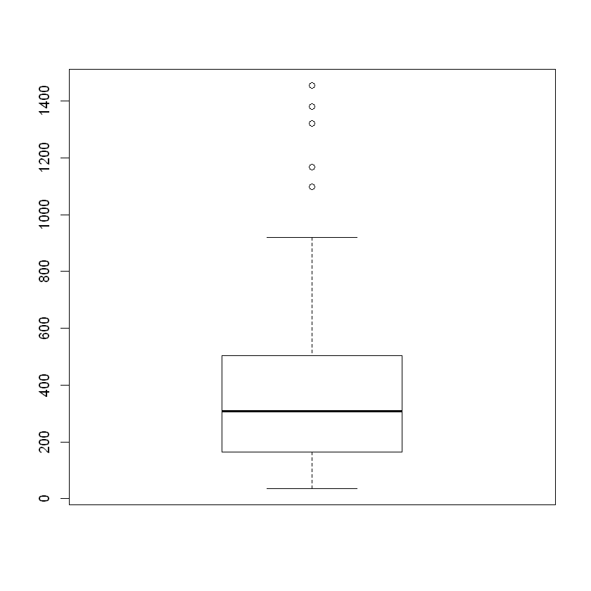

```r
# bar plot을 그려 이상치를 확인한다.

par(mfrow = c(1, 1), oma=c(0,0,0,0))
boxplot(diag(data3))
```

### 전체 데이터 중 이상치의 비율이 4% 정도인 5명의 이상치가 발견되었기 때문에 이를 클러스터링을 통해 해결하고자 한다.

## Clustering Process

### - Hierarchical agglomerative clustering

```r
##library setting
if(!require(cluster)){install.packages('cluster') ; library(cluster)}
```

```r
hc.complete=hclust(dist(data4), method="complete") # 완전연결 (최대 클러스터 간 비유사성)
hc.average=hclust(dist(data4), method="average")   # 평균연결 (평균 클러스터 간 비유사성)
hc.single=hclust(dist(data4), method="single")     # 단일연결 (최소 클러스터 간 비유사성)
```

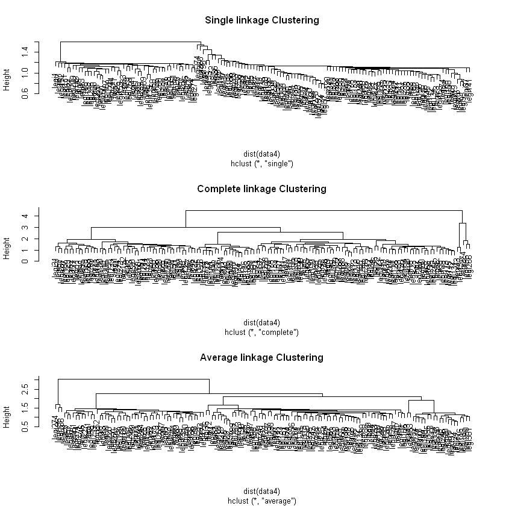

```r
# Single, Complete, Average Clustering Dendrogram을 그려본다.
par(mfrow = c(3, 1))
plot(hc.single, main = 'Single linkage Clustering')
plot(hc.complete, main = 'Complete linkage Clustering')
plot(hc.average, main = 'Average linkage Clustering')
```

#### Single linkage 방법 보다는 Complete linkage나 Average linkage 방법이 군집을 더 골고루 퍼져있다. 그 중에서도 5명의 이상치를 잡기 위해 이상치에 덜 민감한 Average 방법 선택해 군집을 나눠본다.

```r
# 그래프를 볼 때 적절한 군집의 수는 3~5개라고 판단이 되기에 3개의 군집으로 절단해 본다.
x <- cutree(hc.average, 3)
```

### cluster1의 국회의원

```r
names(x)[x==1]
```

1. 'legi1'

2. 'legi8'

3. 'legi11'

4. 'legi13'

5. 'legi23'

6. 'legi26'

7. 'legi27'

8. 'legi30'

9. 'legi31'

10. 'legi38'

11. 'legi40'

12. 'legi41'

13. 'legi46'

14. 'legi50'

15. 'legi51'

16. 'legi57'

17. 'legi62'

18. 'legi67'

19. 'legi71'

20. 'legi83'

21. 'legi89'

22. 'legi107'

23. 'legi119'

24. 'legi139'

25. 'legi149'

26. 'legi152'

27. 'legi158'

28. 'legi159'

29. 'legi161'

30. 'legi171'

31. 'legi177'

32. 'legi179'

33. 'legi180'

34. 'legi186'

35. 'legi200'

36. 'legi206'

37. 'legi207'

38. 'legi209'

39. 'legi214'

40. 'legi220'

41. 'legi227'

42. 'legi229'

43. 'legi239'

44. 'legi244'

45. 'legi260'

46. 'legi269'

47. 'legi271'

48. 'legi285'

### cluster2의 국회의원

```r
names(x)[x==2]
```

1. 'legi2'

2. 'legi5'

3. 'legi9'

4. 'legi12'

5. 'legi15'

6. 'legi16'

7. 'legi17'

8. 'legi18'

9. 'legi19'

10. 'legi20'

11. 'legi24'

12. 'legi33'

13. 'legi35'

14. 'legi36'

15. 'legi37'

16. 'legi42'

17. 'legi43'

18. 'legi60'

19. 'legi64'

20. 'legi72'

21. 'legi73'

22. 'legi74'

23. 'legi79'

24. 'legi80'

25. 'legi81'

26. 'legi84'

27. 'legi85'

28. 'legi87'

29. 'legi92'

30. 'legi94'

31. 'legi95'

32. 'legi101'

33. 'legi106'

34. 'legi111'

35. 'legi112'

36. 'legi113'

37. 'legi114'

38. 'legi116'

39. 'legi118'

40. 'legi120'

41. 'legi126'

42. 'legi128'

43. 'legi131'

44. 'legi132'

45. 'legi133'

46. 'legi134'

47. 'legi135'

48. 'legi137'

49. 'legi141'

50. 'legi144'

51. 'legi145'

52. 'legi147'

53. 'legi150'

54. 'legi151'

55. 'legi153'

56. 'legi155'

57. 'legi156'

58. 'legi160'

59. 'legi168'

60. 'legi175'

61. 'legi183'

62. 'legi188'

63. 'legi189'

64. 'legi190'

65. 'legi192'

66. 'legi195'

67. 'legi199'

68. 'legi203'

69. 'legi210'

70. 'legi213'

71. 'legi219'

72. 'legi223'

73. 'legi225'

74. 'legi228'

75. 'legi233'

76. 'legi235'

77. 'legi236'

78. 'legi241'

79. 'legi242'

80. 'legi246'

81. 'legi248'

82. 'legi256'

83. 'legi259'

84. 'legi261'

85. 'legi267'

86. 'legi278'

87. 'legi280'

88. 'legi284'

89. 'legi288'

90. 'legi301'

### cluster3의 국회의원

```r
names(x)[x==3]
```

1. 'legi196'

2. 'legi266'

3. 'legi274'

### Cluster 된 국회 의원들의 정당을 살펴 본다.

### cluster1의 국회의원 정당 정보

```r
data5 <- cbind(data.frame(x), party)
data5$party[which(data5$x==1)]
```

1. 바른정당

2. 자유한국당

3. 자유한국당

4. 자유한국당

5. 자유한국당

6. 자유한국당

7. 자유한국당

8. 자유한국당

9. 바른정당

10. 자유한국당

11. 자유한국당

12. 자유한국당

13. 자유한국당

14. 자유한국당

15. 자유한국당

16. 바른정당

17. 자유한국당

18. 자유한국당

19. 자유한국당

20. 자유한국당

21. 자유한국당

22. 자유한국당

23. 자유한국당

24. 자유한국당

25. 자유한국당

26. 자유한국당

27. 자유한국당

28. 자유한국당

29. 바른정당

30. 자유한국당

31. 자유한국당

32. 자유한국당

33. 자유한국당

34. 자유한국당

35. 자유한국당

36. 자유한국당

37. 자유한국당

38. 자유한국당

39. 바른정당

40. 자유한국당

41. 바른정당

42. 자유한국당

43. 자유한국당

44. 자유한국당

45. 자유한국당

46. 자유한국당

47. 바른정당

48. 자유한국당

### cluster2의 국회의원 정당 정보

```r
data5$party[which(data5$x==2)]
```

1. 더불어민주당

2. 더불어민주당

3. 더불어민주당

4. 더불어민주당

5. 국민의당

6. 더불어민주당

7. 더불어민주당

8. 더불어민주당

9. 더불어민주당

10. 국민의당

11. 국민의당

12. 더불어민주당

13. 더불어민주당

14. 더불어민주당

15. 국민의당

16. 더불어민주당

17. 국민의당

18. 더불어민주당

19. 더불어민주당

20. 더불어민주당

21. 더불어민주당

22. 더불어민주당

23. 더불어민주당

24. 더불어민주당

25. 더불어민주당

26. 더불어민주당

27. 더불어민주당

28. 더불어민주당

29. 더불어민주당

30. 더불어민주당

31. 더불어민주당

32. 더불어민주당

33. 더불어민주당

34. 더불어민주당

35. 더불어민주당

36. 더불어민주당

37. 국민의당

38. 국민의당

39. 더불어민주당

40. 더불어민주당

41. 무소속

42. 더불어민주당

43. 더불어민주당

44. 국민의당

45. 더불어민주당

46. 국민의당

47. 더불어민주당

48. 더불어민주당

49. 더불어민주당

50. 국민의당

51. 더불어민주당

52. 정의당

53. 더불어민주당

54. 더불어민주당

55. 국민의당

56. 더불어민주당

57. 더불어민주당

58. 국민의당

59. 더불어민주당

60. 더불어민주당

61. 국민의당

62. 더불어민주당

63. 더불어민주당

64. 더불어민주당

65. 국민의당

66. 국민의당

67. 국민의당

68. 국민의당

69. 더불어민주당

70. 더불어민주당

71. 국민의당

72. 더불어민주당

73. 국민의당

74. 더불어민주당

75. 더불어민주당

76. 더불어민주당

77. 국민의당

78. 더불어민주당

79. 더불어민주당

80. 국민의당

81. 더불어민주당

82. 더불어민주당

83. 더불어민주당

84. 더불어민주당

85. 더불어민주당

86. 국민의당

87. 국민의당

88. 더불어민주당

89. 더불어민주당

90. 국민의당

### cluster3의 국회의원 정당 정보

```r
data5$party[which(data5$x==3)]
```

1. 더불어민주당

2. 더불어민주당

3. 더불어민주당

```r
# Table을 이용하여 각 정당의 분포를 확인

table(data5$party[which(data5$x==1)])
table(data5$party[which(data5$x==2)])
table(data5$party[which(data5$x==3)])
```

```
    국민의당 더불어민주당       무소속     바른정당   자유한국당       정의당
           0            0            0            7           41            0
```

```
    국민의당 더불어민주당       무소속     바른정당   자유한국당       정의당
          24           64            1            0            0            1
```

```
    국민의당 더불어민주당       무소속     바른정당   자유한국당       정의당
           0            3            0            0            0            0
```

### Cluster 2 에만 4개의 정당이 속해 있으므로 이를 나눠줄 수 있는지 확인하기 위해 군집 갯수를 하나 추가한다.

```r
# 군집 갯수 추가
x <- cutree(hc.average, 4)
data5 <- cbind(data.frame(x), party)

# Table을 이용하여 각 정당의 분포를 확인
table(data5$party[which(data5$x==1)])
table(data5$party[which(data5$x==2)])
table(data5$party[which(data5$x==3)])
table(data5$party[which(data5$x==4)])
```

```
    국민의당 더불어민주당       무소속     바른정당   자유한국당       정의당
           0            0            0            7           41            0
```

```
    국민의당 더불어민주당       무소속     바른정당   자유한국당       정의당
           2           64            1            0            0            1
```

```
    국민의당 더불어민주당       무소속     바른정당   자유한국당       정의당
          22            0            0            0            0            0
```

```
    국민의당 더불어민주당       무소속     바른정당   자유한국당       정의당
           0            3            0            0            0            0
```

### - Partitioning clustering (k-medoids)

#### - 5개의 이상치를 잡기 위해 Average Linkage Clustering 방법보다 좀 더 심화된 K-medoids 모델을 사용해 본다.

#### - 이 방법은 k-means의 한 종류로 k-means가 임의의 좌표를 중심점으로 잡는 반면, k-medoids는 실제 점 하나를 중심점으로 잡아 계산을 수행한다. 따라서 더 robust한 방법이라고 할 수 있고 이상치에 덜 민감하게 군집을 분류해준다.

```r
# 4개의 군집으로 군집 분석을 수행
# 각 의원들의 군집 번호를 data.frame에 할당하고, 정당 정보를 결합

a <- pam(data4, 4)

newdata <- cbind(data.frame(a$clustering), party)
newdata <- newdata[,-2]
head(newdata)
```

|  | a.clustering | party |
| --- | --- | --- |
| legi1 | 1 | 바른정당 |
| legi2 | 2 | 더불어민주당 |
| legi5 | 3 | 더불어민주당 |
| legi8 | 1 | 자유한국당 |
| legi9 | 3 | 더불어민주당 |
| legi11 | 1 | 자유한국당 |

```r
# Table을 보여준다.
table(newdata$party[which(newdata$a.clustering==1)])
table(newdata$party[which(newdata$a.clustering==2)])
table(newdata$party[which(newdata$a.clustering==3)])
table(newdata$party[which(newdata$a.clustering==4)])
```

```
    국민의당 더불어민주당       무소속     바른정당   자유한국당       정의당
           0            0            0            7           41            0
```

```
    국민의당 더불어민주당       무소속     바른정당   자유한국당       정의당
           0           50            0            0            0            0
```

```
    국민의당 더불어민주당       무소속     바른정당   자유한국당       정의당
           2           17            1            0            0            1
```

```
    국민의당 더불어민주당       무소속     바른정당   자유한국당       정의당
          22            0            0            0            0            0
```

## Visualization of Clustering (k-medoids, k=4)

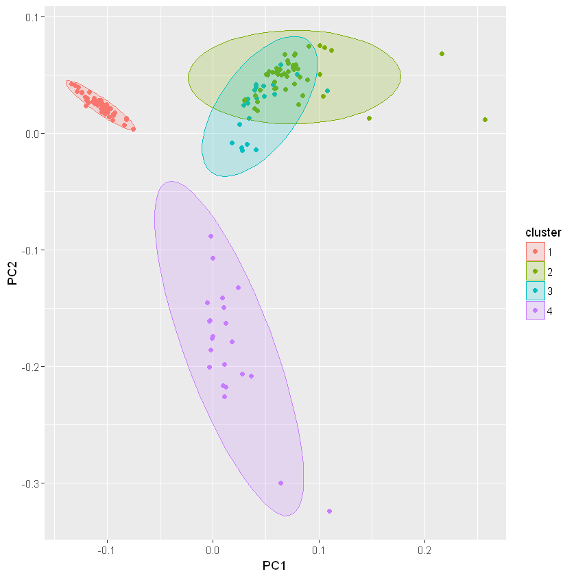

```r
if(!require(ggfortify)){install.packages('ggfortify') ; library(ggfortify)}
autoplot(pam(data4, 4), frame = TRUE, frame.type = 'norm') # 군집의 수를 3~6으로 늘려가면서 관측하자
```

#### 보라색 군집 Cluster 4의 경우 국민의당 의원들만 소속된 군집

## Visualization of Clustering (k-medoids, k=5)

### K=4일 때 정당을 중심으로 군집되었기에 정당을 초월한 군집이 생길지 알아보기 위해 군집 갯수를 늘려 확인해본다.

```
Too few points to calculate an ellipse
```

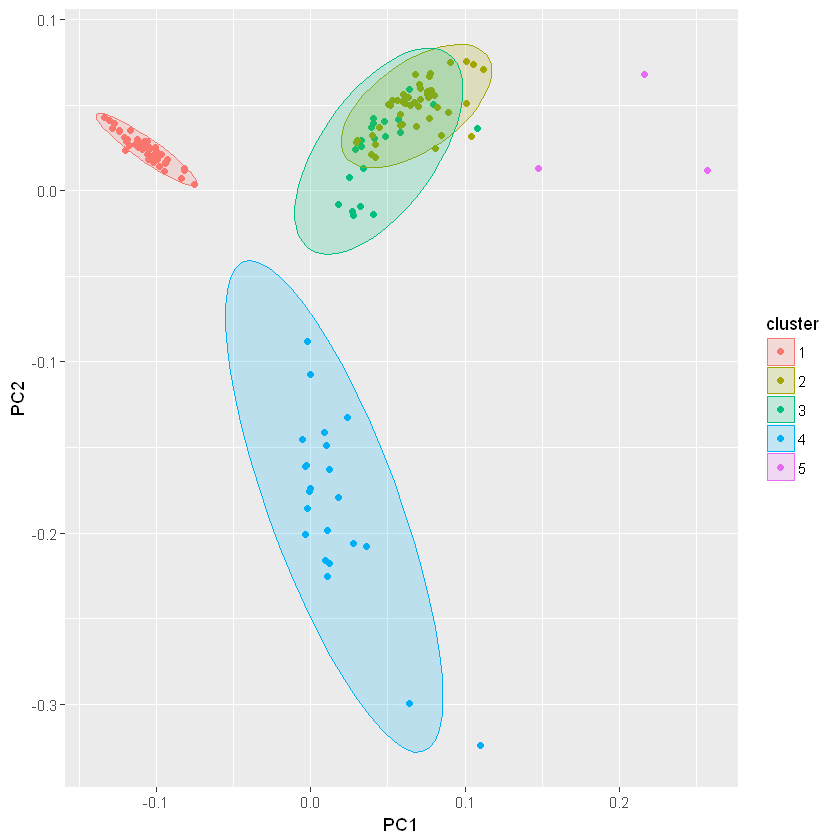

```r
autoplot(pam(data4, 5), frame = TRUE, frame.type = 'norm')
```

#### 군집을 5개로 늘렸을 때, 민주당 의원 3명이 새로 군집을 형성하는 모습이 확인 가능하다.

#### PC1 축을 기준으로 가장 우측에 해당하는 3개의 점이 분류된 것으로 보아 다른 민주당 의원들에 비해 PC1을 기준으로 더 뚜렷한 특성을 지닌 의원들이라고 판단 가능하다.

### Visualization of Clustering (k-medoids, k=6)

```
Too few points to calculate an ellipse
```

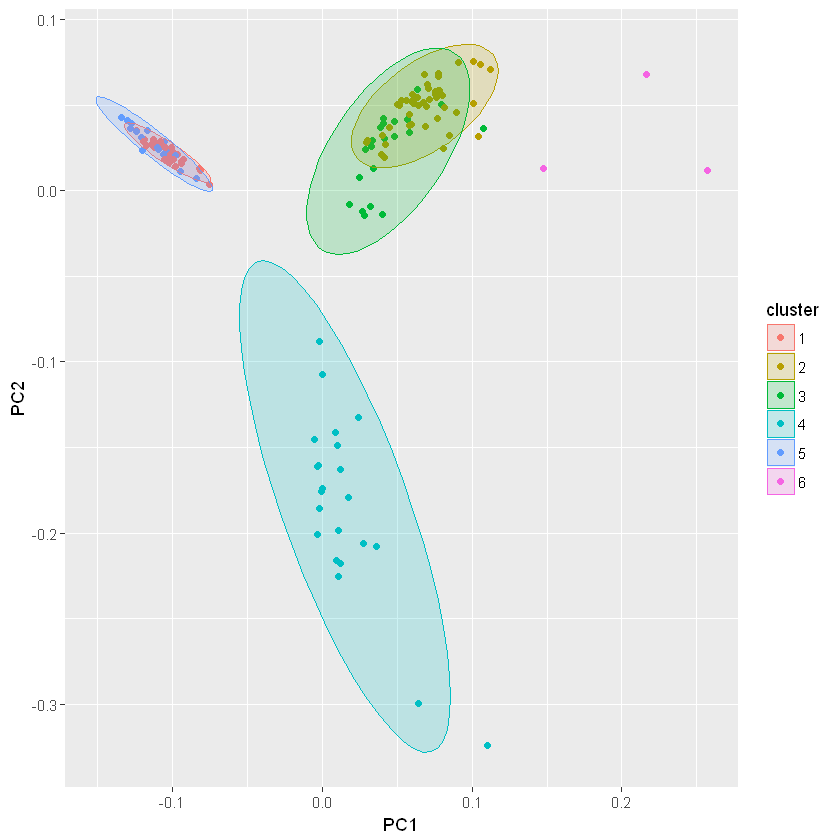

```r
autoplot(pam(data4, 6), frame = TRUE, frame.type = 'norm')
```

#### 가장 먼저 PC1의 경우 보수적 성향을 가진 바른정당과 자유한국당이 0을 기준으로 좌측에 위치

#### 진보적 성향을 가진 국민의당과 더불어민주당이 0을 기준으로 우측에 위치

#### PC1이 높은 값을 가질 수록 진보적인 성향이 뚜렷한 것을 의미한다고 판단

#### PC2의 경우 0을 기준으로 바른정당, 자유한국당, 더불어민주당에 속하는 의원들이 위에 분포

#### 국민의당 의원들은 0을 기준으로 아래쪽에 분포

#### 국민 의당은 PC2의 값이 낮다는 것을 알 수 있다.

## 새로운 행렬 적용

#### 국회의원의 총 공동 발의 건수로 타 의원과의 협력도를 측청하는 것에 한계가 있다고 판단하여 공동 발의 법안의 총 합을 각 원소로 나누는 새로운 행렬을 적용하였다.

```r
frame<- data2
nndata = NULL
for ( i in 1:141){
  for ( j in 1:141){
    if(data2[i,j] != data2[i,i]){
      nndata = data2[i,j]/sum(data2[i,-i])
      frame[i,j] = nndata
    }
  }
}

# 자기 자신에 해당하는 부분은 0으로 변환
frame1=frame
for ( i in 1:141){
  frame1[i,i]=0
}

# 매트릭스화
matrix1 <- data.matrix(frame1, rownames.force = NA)

# 행렬전치
tmp = NULL
for (i in 1:141)
{
  tmp = cbind(tmp, matrix1[i,])
}

colnames(tmp) = rownames(tmp)

# 당이름으로된 열 추가
tmp = cbind(party, tmp)
tmp = tmp[,-1] # id열 제거
```

```r
tmp2 <- tmp[,-1]
c = pam(tmp2, 6)
```

```r
c1 = c$clustering[c$clustering == 1]
c2 = c$clustering[c$clustering == 2]
c3 = c$clustering[c$clustering == 3]
c4 = c$clustering[c$clustering == 4]
c5 = c$clustering[c$clustering == 5]
c6 = c$clustering[c$clustering == 6]
```

```r
cdata <- cbind(data.frame(c$clustering), party) # 정당 값들 결합
cdata2 <- cdata[,-2]
head(cdata2)
```

|  | c.clustering | party |
| --- | --- | --- |
| legi1 | 1 | 바른정당 |
| legi2 | 2 | 더불어민주당 |
| legi5 | 2 | 더불어민주당 |
| legi8 | 3 | 자유한국당 |
| legi9 | 2 | 더불어민주당 |
| legi11 | 1 | 자유한국당 |

```r
if(!require(factoextra)){install.packages('factoextra') ; library(factoextra)}
```

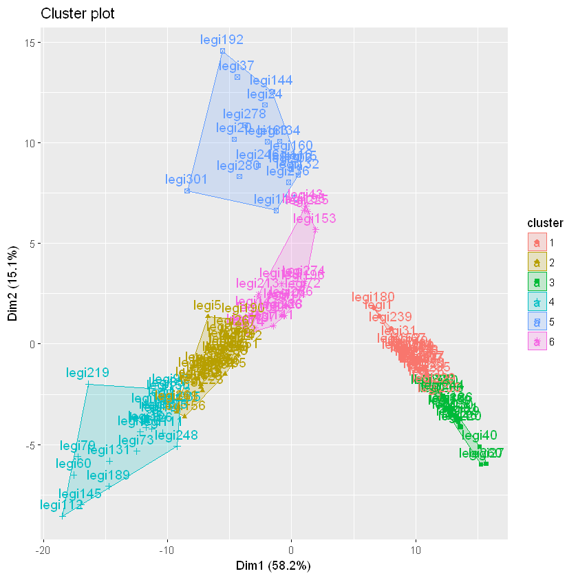

```r
fviz_cluster(c)
```

#### Cluster1, Cluster3은 자유한국당, 바른정당 의원들이 속해있는 군집

#### Cluster2에는 더불어민주당 의원들이 속해있는 군집

#### Cluster4에는 더불어민주당, 국민의당, 무소속 의원들이 속해있는 군집

#### Cluster5는 국민의당 의원들만 속해있는 군집

#### Cluster6 처럼 국민의당과 더불어민주당 의원들이 함께 속해있는 군집

```r
# 각 클러스터에 속해있는 의원들의 정당 분포를 Table로 그려본다.

table(cdata2$party[which(cdata2$c.clustering==1)]) # 바른정당 6 / 자유한국당 23
table(cdata2$party[which(cdata2$c.clustering==2)]) # 더불어민주당 32
table(cdata2$party[which(cdata2$c.clustering==3)]) # 바른정당 1 / 자유한국당 18
table(cdata2$party[which(cdata2$c.clustering==4)]) # 국민의당 1 / 더불어민주당 21 / 무소속 1
table(cdata2$party[which(cdata2$c.clustering==5)]) # 국민의당 18
table(cdata2$party[which(cdata2$c.clustering==6)]) # 국민의당 5 / 더불어민주당 14 / 정의당 1
```

```
    국민의당 더불어민주당       무소속     바른정당   자유한국당       정의당
           0            0            0            6           23            0
```

```
    국민의당 더불어민주당       무소속     바른정당   자유한국당       정의당
           0           32            0            0            0            0
```

```
    국민의당 더불어민주당       무소속     바른정당   자유한국당       정의당
           0            0            0            1           18            0
```

```
    국민의당 더불어민주당       무소속     바른정당   자유한국당       정의당
           1           21            1            0            0            0
```

```
    국민의당 더불어민주당       무소속     바른정당   자유한국당       정의당
          18            0            0            0            0            0
```

```
    국민의당 더불어민주당       무소속     바른정당   자유한국당       정의당
           5           14            0            0            0            1
```

### 당 간의 협업 정도 측정

```r
library(ggplot2)

partyFreq = function(data, cluster)
{
  outPut = NULL
  for (i in 1:length(cluster))
  {
    partySum = c()
    g = sum(data[,colnames(data) == names(cluster[i])][which(data$party == '국민의당')])
    d = sum(data[,colnames(data) == names(cluster[i])][which(data$party == '더불어민주당')])
    f = sum(data[,colnames(data) == names(cluster[i])][which(data$party == '자유한국당')])
    b = sum(data[,colnames(data) == names(cluster[i])][which(data$party == '바른정당')])
    j = sum(data[,colnames(data) == names(cluster[i])][which(data$party == '정의당')])
    m = sum(data[,colnames(data) == names(cluster[i])][which(data$party == '무소속')])
    partySum = c(g, d, f, b, j, m)
    names(partySum) = c('국민의당', '더불어민주당', '자유한국당', '바른정당', '정의당', '무소속')

    outPut = rbind(outPut, partySum)
    rownames(outPut)[i] = names(cluster[i])
  }
  print('아래는 각 의원의 정당별 협업 정도 데이터프레임')
  print(outPut)
  result = colSums(outPut)/length(cluster)
  result2 = transform(result)
  result2 = cbind(rownames(result2), result2)
  colnames(result2) = c('Party', 'Proposition')
  pie<- ggplot(result2, aes(x='', y=Proposition, fill=Party))+
    geom_bar(width = 1, stat = "identity") + coord_polar("y", start = 0)
  plot(pie)
  return(result)
}
```

```
[1] "아래는 각 의원의 정당별 협업 정도 데이터프레임"
          국민의당 더불어민주당 자유한국당   바른정당       정의당       무소속
legi1   0.07225434   0.19219653  0.5549133 0.17052023 0.0000000000 0.0101156069
legi11  0.03580786   0.08122271  0.7982533 0.08296943 0.0000000000 0.0017467249
legi23  0.04023973   0.04880137  0.8142123 0.09503425 0.0000000000 0.0017123288
legi26  0.04578488   0.13081395  0.7558140 0.06613372 0.0007267442 0.0007267442
legi31  0.05786026   0.15174672  0.6179039 0.16812227 0.0000000000 0.0043668122
legi41  0.03973988   0.05491329  0.8179191 0.08381503 0.0000000000 0.0036127168
legi57  0.07484568   0.16435185  0.6257716 0.12962963 0.0007716049 0.0046296296
legi62  0.02487562   0.06467662  0.8338308 0.07562189 0.0000000000 0.0009950249
legi67  0.03023516   0.04815230  0.8073908 0.11198208 0.0011198208 0.0011198208
legi71  0.01331853   0.01664817  0.8845727 0.08546060 0.0000000000 0.0000000000
legi83  0.07254290   0.12792512  0.7184087 0.07488300 0.0000000000 0.0062402496
legi107 0.04069264   0.08225108  0.7774892 0.09870130 0.0000000000 0.0008658009
legi149 0.05405405   0.11611612  0.7517518 0.07707708 0.0000000000 0.0010010010
legi152 0.09369818   0.20480929  0.6160862 0.08374793 0.0008291874 0.0008291874
legi158 0.04514890   0.07108549  0.7195005 0.15658021 0.0000000000 0.0076849183
legi161 0.03878407   0.06603774  0.7127883 0.17714885 0.0010482180 0.0041928721
legi171 0.02970297   0.06848185  0.8341584 0.06435644 0.0000000000 0.0033003300
legi177 0.03380783   0.05427046  0.8354093 0.07295374 0.0000000000 0.0035587189
legi179 0.02073050   0.06317868  0.8469891 0.06811451 0.0000000000 0.0009871668
legi180 0.07787611   0.11681416  0.7610619 0.03893805 0.0000000000 0.0053097345
legi206 0.03600000   0.08066667  0.8126667 0.06466667 0.0006666667 0.0053333333
legi207 0.02700096   0.03664417  0.7897782 0.14079074 0.0000000000 0.0057859209
legi209 0.02118644   0.05614407  0.8463983 0.07521186 0.0000000000 0.0010593220
legi214 0.08983051   0.13644068  0.5813559 0.18389831 0.0033898305 0.0050847458
legi229 0.03272727   0.08363636  0.8152727 0.06690909 0.0000000000 0.0014545455
legi239 0.10110974   0.14673243  0.5622688 0.18002466 0.0000000000 0.0098643650
legi269 0.06194690   0.06882989  0.7866273 0.07767945 0.0029498525 0.0019665683
legi271 0.13586207   0.21931034  0.4820690 0.15034483 0.0020689655 0.0103448276
legi285 0.03672788   0.04173623  0.8238731 0.09515860 0.0000000000 0.0025041736
```

**국민의당**

0.0511859266327064

**더불어민주당**

0.09636670104276

**자유한국당**

0.744294320164405

**바른정당**

0.104016359701552

**정의당**

0.000467961744084292

**무소속**

0.00366873071449239

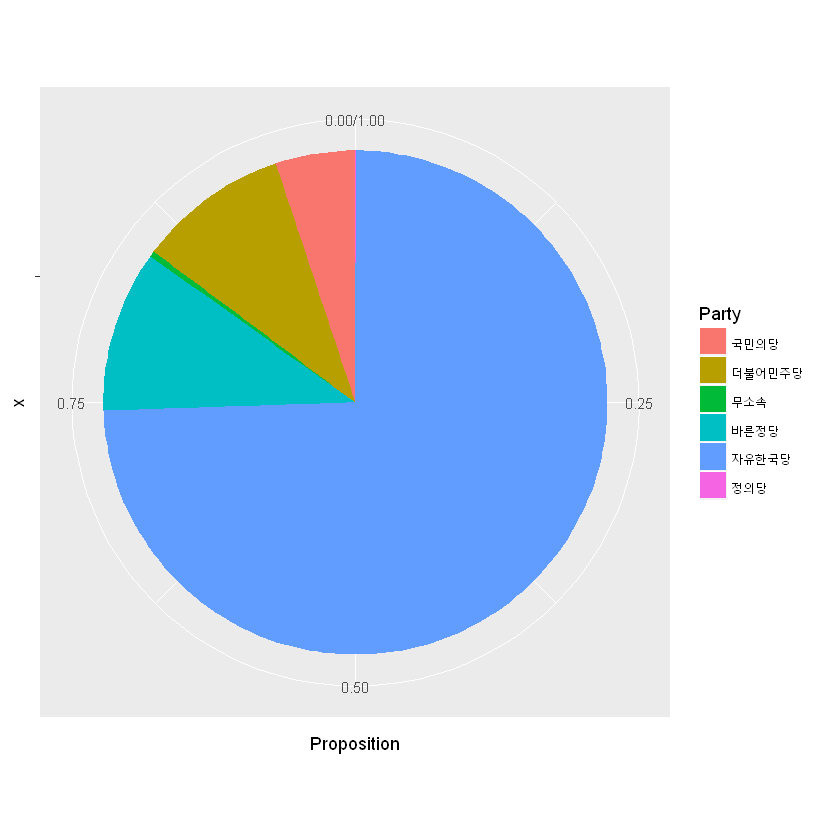

```r
partyFreq(tmp, c1) #클러스터 1의 당 협업 정도
```

```
[1] "아래는 각 의원의 정당별 협업 정도 데이터프레임"
          국민의당 더불어민주당  자유한국당    바른정당      정의당     무소속
legi2   0.08954991    0.8698022 0.008565644 0.002180346 0.006541037 0.02336085
legi5   0.23866232    0.7133768 0.015171289 0.004893964 0.004893964 0.02300163
legi9   0.14370079    0.8215223 0.010279965 0.002405949 0.006124234 0.01596675
legi16  0.12851032    0.8368979 0.007439092 0.002231728 0.004091501 0.02082946
legi19  0.10648392    0.8595150 0.006589352 0.002635741 0.008170796 0.01660517
legi33  0.11681026    0.8531356 0.008214787 0.002003606 0.005810459 0.01402525
legi42  0.13509545    0.8169359 0.016397455 0.003426334 0.007342144 0.02080274
legi64  0.10205745    0.8478305 0.015889183 0.003463027 0.011407619 0.01935221
legi80  0.10866028    0.8526487 0.013921533 0.002711987 0.008316760 0.01374073
legi81  0.13257079    0.8361148 0.004687793 0.002062629 0.008438027 0.01612601
legi84  0.14079115    0.8094428 0.012335177 0.006380264 0.006592939 0.02445768
legi94  0.10866911    0.8533054 0.008198151 0.002267574 0.007849294 0.01971045
legi118 0.10076687    0.8610429 0.007822086 0.002607362 0.006288344 0.02147239
legi128 0.12543728    0.8280860 0.018823921 0.003664834 0.006829918 0.01715809
legi133 0.11069882    0.8367347 0.016491445 0.004535147 0.010925582 0.02061431
legi135 0.09957717    0.8532770 0.025369979 0.003805497 0.004862579 0.01310782
legi151 0.09952129    0.8589065 0.014109347 0.003527337 0.010582011 0.01335349
legi155 0.13907719    0.8020993 0.019680735 0.004154822 0.017493986 0.01749399
legi156 0.10323856    0.8487152 0.021134256 0.002584765 0.005625665 0.01870154
legi188 0.18777388    0.7797984 0.008545136 0.003505697 0.005915863 0.01446100
legi190 0.23543426    0.7104180 0.032921811 0.006930908 0.004331817 0.00996318
legi210 0.09662289    0.8691370 0.005628518 0.001641651 0.005628518 0.02134146
legi223 0.10199318    0.8464715 0.019393069 0.004489136 0.010773927 0.01687915
legi233 0.12999830    0.8221882 0.013272078 0.003062787 0.006806194 0.02467245
legi241 0.09269933    0.8758405 0.005763689 0.002641691 0.004803074 0.01825168
legi242 0.11093951    0.8561133 0.007979408 0.003603604 0.004118404 0.01724582
legi256 0.09983186    0.8596049 0.011979823 0.003152585 0.004623792 0.02080706
legi259 0.12626020    0.8377340 0.005040807 0.001920307 0.008881421 0.02016323
legi261 0.08624400    0.8857805 0.003972852 0.001655355 0.009104453 0.01324284
legi267 0.17297297    0.7898942 0.014336075 0.004465335 0.005170388 0.01316099
legi284 0.09749750    0.8626627 0.010810811 0.003203203 0.005605606 0.02022022
legi288 0.10916534    0.8442120 0.014555379 0.003411417 0.008414828 0.02024107
```

**국민의당**

0.124291004631332

**더불어민주당**

0.834351399361858

**자유한국당**

0.0126662701065902

**바른정당**

0.00328833086878655

**정의당**

0.00726141075763231

**무소속**

0.0181415842738008

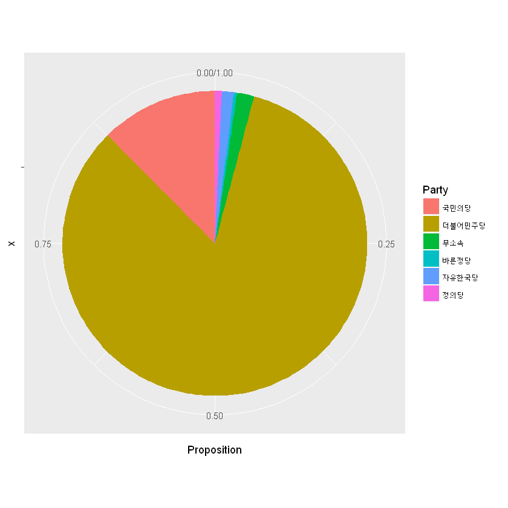

```r
partyFreq(tmp, c2) #클러스터 2의 당 협업 정도
```

```
[1] "아래는 각 의원의 정당별 협업 정도 데이터프레임"
          국민의당 더불어민주당 자유한국당   바른정당       정의당       무소속
legi8   0.04668166   0.08492688  0.7750281 0.09055118 0.0000000000 0.0028121485
legi13  0.04573341   0.10764083  0.7629671 0.08031233 0.0005577245 0.0027886224
legi27  0.03811174   0.08878302  0.7964487 0.07492421 0.0008661758 0.0008661758
legi30  0.02311436   0.05352798  0.8497567 0.07238443 0.0000000000 0.0012165450
legi38  0.04327248   0.11561866  0.7599730 0.07572684 0.0006761325 0.0047329277
legi40  0.04771084   0.06457831  0.7966265 0.08674699 0.0009638554 0.0033734940
legi46  0.07479920   0.14658635  0.6435743 0.12851406 0.0005020080 0.0060240964
legi50  0.03801170   0.04824561  0.8369883 0.07602339 0.0000000000 0.0007309942
legi51  0.06519274   0.06122449  0.7964853 0.07539683 0.0000000000 0.0017006803
legi89  0.06699616   0.13289401  0.7029105 0.08182317 0.0054914882 0.0098846787
legi119 0.03286385   0.07511737  0.8182428 0.07109323 0.0006706908 0.0020120724
legi139 0.08682635   0.11477046  0.7175649 0.07584830 0.0000000000 0.0049900200
legi159 0.04629630   0.08950617  0.7895062 0.07345679 0.0000000000 0.0012345679
legi186 0.06666667   0.07728614  0.7687316 0.08141593 0.0017699115 0.0041297935
legi200 0.07017544   0.08834586  0.7481203 0.09147870 0.0006265664 0.0012531328
legi220 0.07445759   0.10650888  0.7366864 0.07593688 0.0029585799 0.0034516765
legi227 0.07102093   0.14648066  0.6417248 0.13443247 0.0006341154 0.0057070387
legi244 0.03635068   0.04704205  0.8346401 0.08125445 0.0000000000 0.0007127584
legi260 0.04468349   0.12618949  0.7579644 0.06826645 0.0012412081 0.0016549441
```

**국민의당**

0.0536297667777696

**더불어민주당**

0.0934354333314934

**자유한국당**

0.764944197623773

**바른정당**

0.0839782431131497

**정의당**

0.000892550348356703

**무소속**

0.00311980880545781

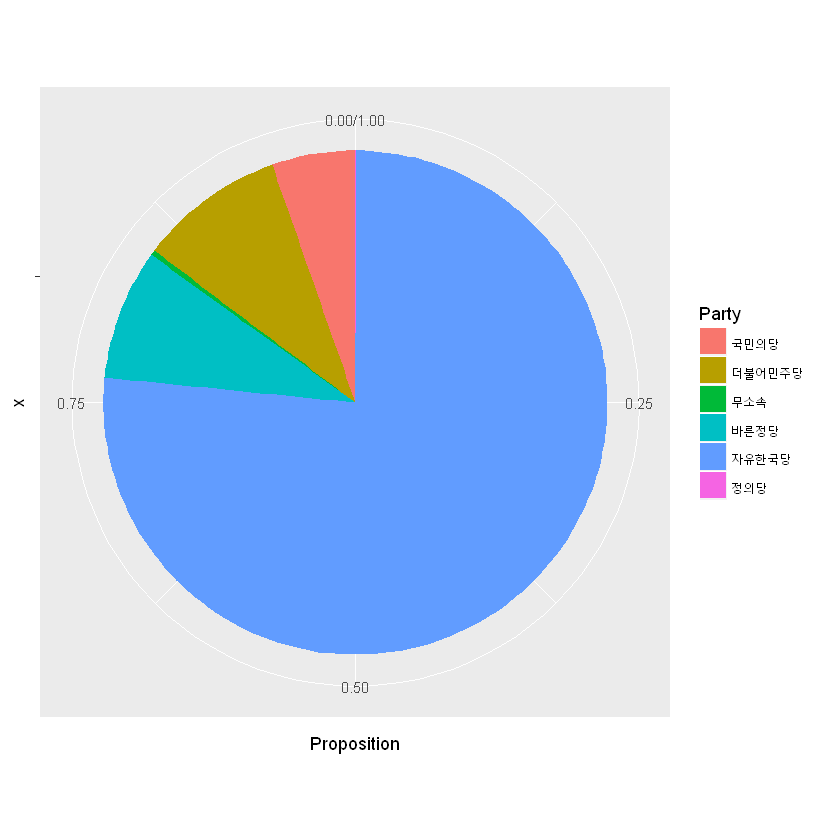

```r
partyFreq(tmp, c3) #클러스터 3의 당 협업 정도
```

```
[1] "아래는 각 의원의 정당별 협업 정도 데이터프레임"
          국민의당 더불어민주당  자유한국당    바른정당      정의당     무소속
legi12  0.10185462    0.8547712 0.008674843 0.002542626 0.007029614 0.02512713
legi18  0.09831502    0.8754579 0.004688645 0.001758242 0.004688645 0.01509158
legi35  0.11164985    0.8553270 0.007076399 0.002096711 0.006814310 0.01703578
legi60  0.13016874    0.8274615 0.006582607 0.001576117 0.008436863 0.02577415
legi73  0.11042588    0.8466372 0.016406795 0.004072609 0.004421690 0.01803584
legi79  0.16669715    0.7916057 0.006858083 0.001463058 0.008138259 0.02523775
legi85  0.15942776    0.7865704 0.022941101 0.005413069 0.005928599 0.01971904
legi92  0.14114902    0.8152523 0.012394284 0.002916302 0.010936133 0.01735200
legi95  0.13718559    0.8259687 0.009245411 0.002447315 0.005574439 0.01957852
legi111 0.10895248    0.8378840 0.018771331 0.004200578 0.004856918 0.02533473
legi112 0.10707772    0.8500217 0.012331741 0.003039514 0.004342162 0.02318715
legi113 0.13356116    0.8214438 0.013242204 0.003559732 0.005980350 0.02221273
legi120 0.11917314    0.8404550 0.005688124 0.001664817 0.008601554 0.02441731
legi126 0.13981265    0.8262295 0.020023419 0.005971897 0.007962529 0.00000000
legi131 0.10612028    0.8569452 0.008621607 0.001490154 0.005854178 0.02096860
legi145 0.08438275    0.8826971 0.005651958 0.001388200 0.005751116 0.02012890
legi150 0.16055363    0.7946021 0.011626298 0.004152249 0.005536332 0.02352941
legi168 0.13794716    0.8210194 0.017184943 0.003156418 0.004559271 0.01613280
legi175 0.08366904    0.8813139 0.005268051 0.002014255 0.009761388 0.01797335
legi189 0.11767713    0.8309989 0.022083632 0.004600757 0.007872406 0.01676720
legi219 0.20331695    0.7564058 0.016233766 0.003422253 0.003597754 0.01702352
legi235 0.11669392    0.8364799 0.017541252 0.003270403 0.006986770 0.01902780
legi248 0.14409522    0.7608043 0.054194592 0.009706494 0.009475387 0.02172406
```

**국민의당**

0.126952471758644

**더불어민주당**

0.829406621236445

**자유한국당**

0.0140578733326757

**바른정당**

0.00330103344204873

**정의당**

0.00665681152767978

**무소속**

0.0196251887025067

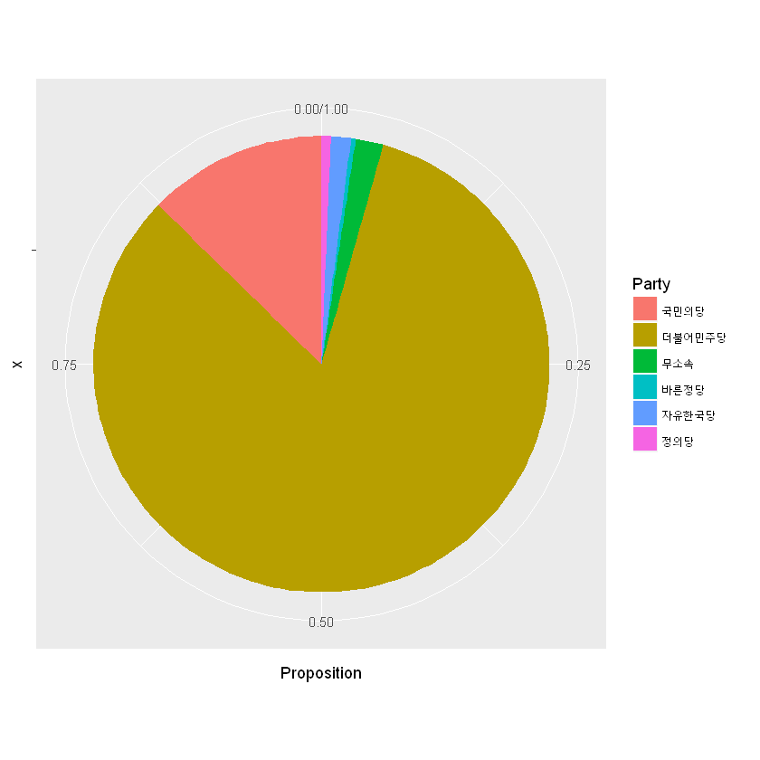

```r
partyFreq(tmp, c4) #클러스터 4의 당 협업 정도
```

```
[1] "아래는 각 의원의 정당별 협업 정도 데이터프레임"
         국민의당 더불어민주당 자유한국당    바른정당      정의당      무소속
legi15  0.6689715    0.3059637 0.01037165 0.003889369 0.004753673 0.006050130
legi20  0.4985342    0.4407166 0.03175896 0.005211726 0.009934853 0.013843648
legi24  0.6423618    0.3154024 0.01996218 0.006513974 0.004622820 0.011136793
legi37  0.5896920    0.3564464 0.02987154 0.004798019 0.005881443 0.013310633
legi114 0.4626910    0.4885429 0.02761457 0.006169213 0.007050529 0.007931845
legi116 0.6132859    0.3247331 0.04240807 0.008600237 0.003262159 0.007710558
legi132 0.6204819    0.3437751 0.02008032 0.006425703 0.002811245 0.006425703
legi134 0.6294832    0.3275911 0.02541655 0.007624965 0.004518498 0.005365716
legi144 0.6837715    0.2851365 0.01466127 0.003538928 0.004802831 0.008088979
legi160 0.6381891    0.3201899 0.01971522 0.005111355 0.005476451 0.011317999
legi183 0.5646050    0.3798734 0.03327210 0.008164932 0.003878343 0.010206165
legi192 0.5984263    0.3573992 0.02277747 0.006902264 0.003589177 0.010905577
legi203 0.6179931    0.3474048 0.02110727 0.003114187 0.004498270 0.005882353
legi236 0.5477354    0.4024112 0.03356142 0.006190942 0.004887586 0.005213425
legi246 0.5288951    0.4285714 0.01618123 0.005316690 0.010402219 0.010633380
legi278 0.5517177    0.4096565 0.01411328 0.006128134 0.007985144 0.010399257
legi280 0.4565252    0.4781434 0.04101097 0.006517247 0.005563503 0.012239708
legi301 0.4008128    0.5131840 0.05339760 0.010868538 0.005670542 0.016066534
```

**국민의당**

0.573009591603553

**더불어민주당**

0.379174532579762

**자유한국당**

0.0265156476688186

**바른정당**

0.00617146779988738

**정의당**

0.00553273805958484

**무소속**

0.00959602228839448

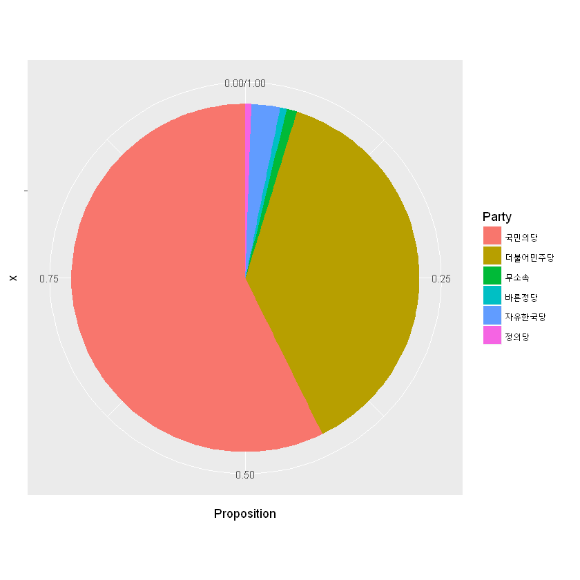

```r
partyFreq(tmp, c5) #클러스터 5의 당 협업 정도
```

```
[1] "아래는 각 의원의 정당별 협업 정도 데이터프레임"
         국민의당 더불어민주당  자유한국당    바른정당      정의당      무소속
legi17  0.1259653    0.8354247 0.016409266 0.004826255 0.004826255 0.012548263
legi36  0.1507538    0.7707770 0.044839583 0.012369540 0.009277155 0.011982992
legi43  0.5764834    0.3854110 0.016330974 0.007621121 0.007076756 0.007076756
legi72  0.1510452    0.7956844 0.024275118 0.007417397 0.008766015 0.012811868
legi74  0.1259889    0.8452974 0.006152945 0.002929974 0.008789921 0.010840902
legi87  0.1312818    0.8238283 0.008187465 0.001976285 0.010163749 0.024562394
legi101 0.1566543    0.7837338 0.033733826 0.006931608 0.007393715 0.011552680
legi106 0.1550837    0.8088803 0.014800515 0.003539254 0.006113256 0.011583012
legi137 0.1270667    0.8389467 0.006123699 0.003674219 0.008266993 0.015921617
legi141 0.1256694    0.8154231 0.028561228 0.008925384 0.008925384 0.012495537
legi147 0.1731928    0.7918675 0.011445783 0.003012048 0.000000000 0.020481928
legi153 0.5243902    0.4463415 0.008943089 0.005691057 0.007317073 0.007317073
legi195 0.5469816    0.4078740 0.018372703 0.009448819 0.004724409 0.012598425
legi196 0.1731725    0.7799858 0.026969482 0.006387509 0.007097232 0.006387509
legi199 0.2253695    0.7417898 0.008620690 0.003694581 0.005336617 0.015188834
legi213 0.2329390    0.7261146 0.007279345 0.002729754 0.013042160 0.017895056
legi225 0.5471218    0.3902191 0.043301070 0.005603668 0.005094244 0.008660214
legi228 0.1200000    0.8226263 0.020202020 0.006060606 0.010101010 0.021010101
legi266 0.1344668    0.8109222 0.028335909 0.008758372 0.007212777 0.010303967
legi274 0.1806597    0.7848576 0.009745127 0.005247376 0.010494753 0.008995502
```

**국민의당**

0.234214308254065

**더불어민주당**

0.720300253341978

**자유한국당**

0.0191314918865051

**바른정당**

0.00584224134896704

**정의당**

0.0075009736867196

**무소속**

0.0130107314817645

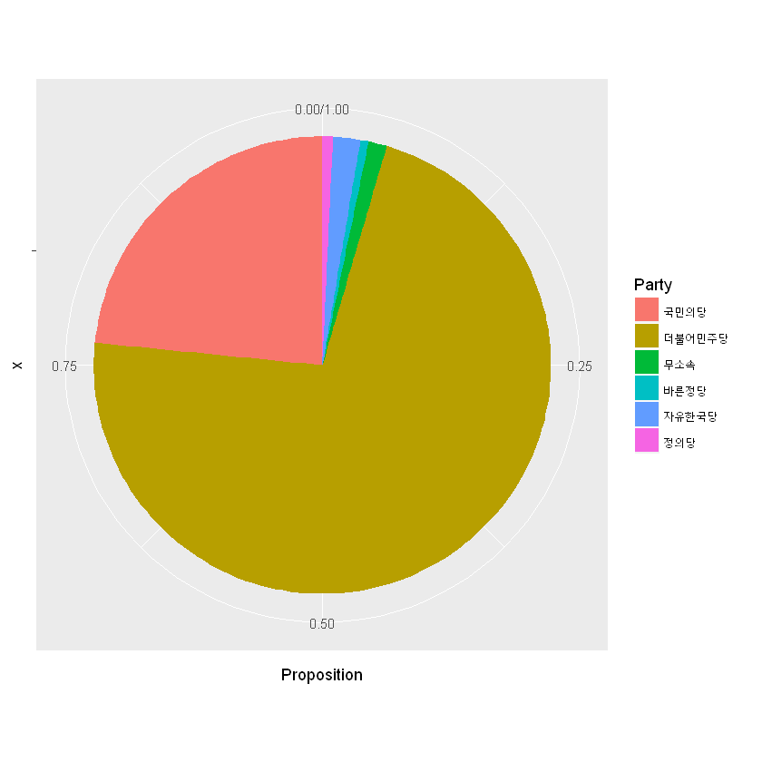

```r
partyFreq(tmp, c6) #클러스터 6의 당 협업 정도
```

### 같은 당끼리 발의한 법안을 제외한 후 당 간의 협업도 비율 측정

```r
party <- read.csv('party.csv', header=T, sep = ',')
party_name = party[,1]
rownames(party) = party_name

fp = party[party$party=="자유한국당",]$id
bp = party[party$party=="바른정당",]$id
gp = party[party$party=="국민의당",]$id
dp = party[party$party=="더불어민주당",]$id
jp = party[party$party=="정의당",]$id
mp = party[party$party=="무소속",]$id
```

```r
party = list(fp, bp, gp, dp, jp, mp) #당에 따른 의원 list에 할당
party_name = c('자유한국당', '바른정당', '국민의당', '더불어민주당', '정의당', '무소속')
party = setNames(party, party_name) #party 리스트이름 지정
```

```r
# 협업/협업sum 비율척도로 바꾼다.
frame<- data2
nndata = NULL
for ( i in 1:141){
  for ( j in 1:141){
    if(data2[i,j] != data2[i,i]){
      nndata = data2[i,j]/sum(data2[i,-i])
      frame[i,j] = nndata
    }
  }
}
#자기 자신에 해당하는 부분은 0으로 변환
frame1=frame
for ( i in 1:141){
  frame1[i,i]=0
}

#매트릭스화
matrix1 <- data.matrix(frame1, rownames.force = NA)


# Divide by diag element
data4 <- matrix1
fp_data = data4[rownames(data4) %in% fp,!(colnames(data4) %in% fp)]
bp_data = data4[rownames(data4) %in% bp,!(colnames(data4) %in% bp)]
gp_data = data4[rownames(data4) %in% gp,!(colnames(data4) %in% gp)]
dp_data = data4[rownames(data4) %in% dp,!(colnames(data4) %in% dp)]
jp_data = data4[rownames(data4) %in% jp,!(colnames(data4) %in% jp)]
mp_data = data4[rownames(data4) %in% mp,!(colnames(data4) %in% mp)]
```

### 자유한국당

#### Cluster Plot (k=2)

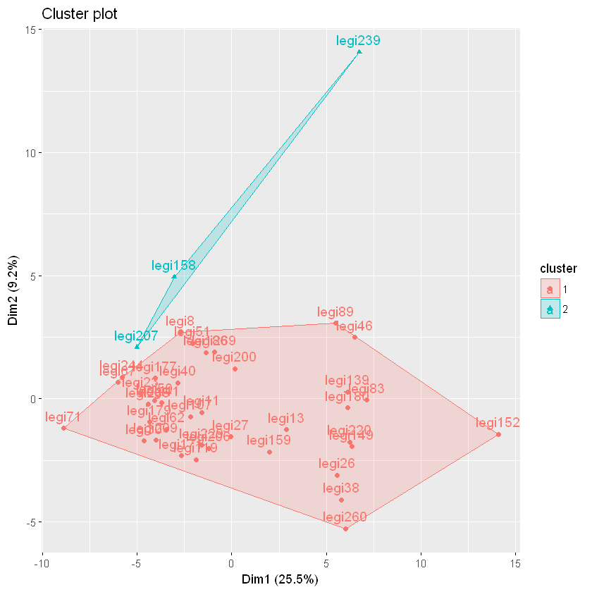

```r
fp_pam = pam(fp_data, 2)
fviz_cluster(fp_pam)
```

### 군집 1에 대한 자유 한국당 의원과 공동 발의한 비율이 높은 타 당의원 Top 3

```r
#군집별 의원
fp_c1 = fp_pam$clustering[fp_pam$clustering == 1]
fp_c2 = fp_pam$clustering[fp_pam$clustering == 2]
```

```r
topSeclect = function(data, cluster)
{
  outPut = c()
  for (i in 1:length(cluster))
  {
    allCong = data[rownames(data) == names(cluster[i]),]
    topThree = head(sort(allCong, decreasing = T), 3)
    print(topThree)
    outPut = c(outPut, names(topThree))
  }
  print(table(outPut))

}
```

```r
topSeclect(fp_data, fp_c1)
```

```
    legi57    legi214    legi227
0.01968504 0.01574803 0.01518560
   legi227     legi57    legi271
0.01746725 0.01397380 0.01222707
   legi227     legi57    legi271
0.01896263 0.01394311 0.01338539
   legi227     legi57    legi214
0.02397260 0.01797945 0.01455479
    legi57    legi214    legi227
0.01526163 0.01162791 0.01162791
   legi227    legi271    legi161
0.01645734 0.01342573 0.01212646
   legi227    legi161    legi271
0.02007299 0.01520681 0.01034063
   legi271    legi227    legi214
0.01960784 0.01487492 0.01284652
   legi227    legi271     legi57
0.02072289 0.02024096 0.01253012
    legi57    legi227     legi31
0.02962428 0.01661850 0.01011561
   legi227    legi271    legi248
0.02710843 0.02359438 0.02309237
   legi227     legi57    legi214
0.02046784 0.01388889 0.01169591
    legi57    legi301    legi227
0.01530612 0.01473923 0.01190476
   legi227    legi161     legi31
0.01592040 0.01393035 0.01293532
   legi227    legi161     legi57
0.03919373 0.01679731 0.01567749
    legi57    legi161    legi227
0.02108768 0.02108768 0.01331853
   legi301    legi227     legi57
0.01716069 0.01638066 0.01248050
   legi271    legi227    legi161
0.01537617 0.01427787 0.01317957
   legi271    legi227     legi31
0.02510823 0.02251082 0.01298701
   legi227    legi214     legi57
0.01609658 0.01475520 0.01274313
```

[output cut: 24 more lines]

```
     legi1    legi271    legi227
0.01676529 0.01676529 0.01282051
   legi227     legi31    legi161
0.01454545 0.01309091 0.01090909
   legi161     legi31     legi57
0.02066999 0.01282965 0.01282965
   legi227     legi57    legi271
0.01613571 0.01489450 0.01406703
   legi227    legi161    legi214
0.01671583 0.01474926 0.01376598
   legi227     legi57    legi214
0.02504174 0.01752922 0.01585977
outPut
  legi1 legi161 legi189 legi214 legi227 legi248 legi271 legi301  legi31  legi57
      2      16       1       9      34       2      14       7       7      22
```

#### 의원들이 속한 당을 파악한 결과, 네 명 모두 바른정당 의원임

### 군집 2에 대한 자유 한국당 의원과 공동 발의한 비율이 높은 타 당의원 Top 3

```r
topSeclect(fp_data, fp_c2)
```

```
   legi214    legi161     legi57
0.03073967 0.02785783 0.02497598
    legi57    legi214     legi31
0.03567985 0.02314368 0.02025072
   legi214    legi271      legi1
0.03822441 0.03082614 0.02959309
outPut
  legi1 legi161 legi214 legi271  legi31  legi57
      1       1       3       1       1       2
```

#### TOP3로 뽑힌 빈도가 높은 의원인 214번/57번 의원 역시 바른정당 의원이었다.

### 더불어민주당

#### Cluster Plot (k=2)

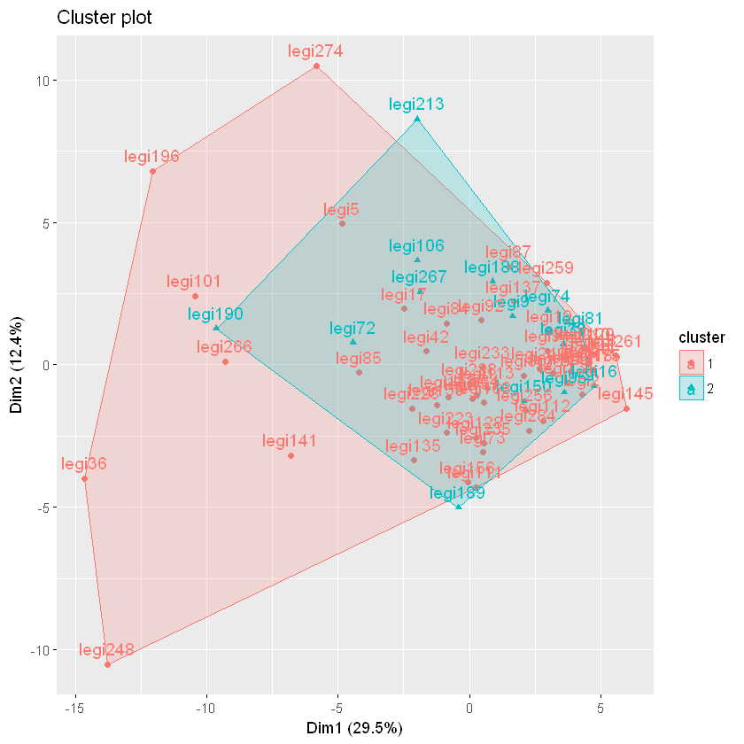

```r
dp_pam = pam(dp_data, 2)
fviz_cluster(dp_pam)
```

### 군집 1에 대한 더불어 민주당 의원과 공동 발의한 비율이 높은 타 당의원 Top 3

```r
#군집별 의원
dp_c1 = dp_pam$clustering[dp_pam$clustering == 1]
dp_c2 = dp_pam$clustering[dp_pam$clustering == 2]
```

```r
topSeclect(dp_data, dp_c1)
```

```
    legi126     legi219     legi301
0.023360847 0.016664071 0.008877122
   legi301    legi280    legi183
0.03099511 0.02691680 0.02414356
   legi126    legi219    legi301
0.02512713 0.01301226 0.01032007
    legi219     legi126     legi199
0.015926641 0.012548263 0.009169884
   legi219    legi126    legi301
0.01655678 0.01509158 0.00967033
   legi126    legi219    legi301
0.01660517 0.01581444 0.01027939
   legi219    legi126    legi301
0.02725724 0.01703578 0.01284235
   legi219    legi301    legi126
0.01816776 0.01314264 0.01198299
   legi126    legi219     legi20
0.02080274 0.01884484 0.01223691
   legi219    legi126    legi301
0.02725756 0.02577415 0.01705915
   legi126    legi301    legi147
0.01935221 0.01201874 0.01140762
   legi126    legi301    legi219
0.01803584 0.01710496 0.01582499
   legi219    legi301    legi126
0.01609112 0.01482553 0.01374073
   legi126    legi219    legi301
0.02445768 0.01807741 0.01509996
   legi126    legi301    legi219
0.01971904 0.01959015 0.01868798
   legi126    legi219    legi301
0.02456239 0.01778656 0.01101073
   legi219    legi126    legi301
0.02508020 0.01735200 0.01589385
    legi126     legi219     legi301
0.019710448 0.013954300 0.009244724
   legi219    legi126    legi301
0.01894640 0.01155268 0.01155268
   legi126    legi219    legi301
0.02533473 0.02231557 0.01562090
```

[output cut: 52 more lines]

```
    legi126     legi219      legi37
0.020163226 0.018242919 0.009841575
    legi219     legi126     legi147
0.016719086 0.013242841 0.009104453
    legi126     legi219     legi301
0.010303967 0.009788769 0.009788769
   legi219     legi37    legi144
0.01199400 0.01124438 0.01049475
    legi219     legi126     legi301
0.021621622 0.020220220 0.007207207
   legi126    legi219    legi301
0.02024107 0.01591995 0.01205367
outPut
legi126 legi144 legi147 legi183 legi199  legi20 legi219 legi280 legi301  legi37
     49       1       6       1       1       2      50       1      43       2
```

#### TOP3로 추출된 빈도수가 높은 의원들을 파악해 보았을 때, 219번/126번/301번/147번 의원 순으로 높은 빈도를 가짐

#### 의원들이 속한 당을 파악한 결과, 순서대로 국민의당/무소속/국민의당/정의당 임

### 군집 2에 대한 더불어 민주당 의원과 공동 발의한 비율이 높은 타 당의원 Top 3

```r
topSeclect(dp_data, dp_c2)
```

```
   legi219    legi126    legi301
0.03674541 0.01596675 0.01487314
   legi219    legi126    legi192
0.05021387 0.02082946 0.01022875
    legi219     legi126     legi301
0.028851933 0.014025245 0.009416951
   legi219    legi192    legi126
0.03371544 0.01550910 0.01281187
   legi219    legi114    legi126
0.03252271 0.01201289 0.01084090
   legi219    legi126    legi301
0.04453182 0.02523775 0.02212875
   legi219    legi126    legi301
0.03543971 0.01612601 0.01237577
   legi219    legi126    legi301
0.04962610 0.01957852 0.01563562
   legi219    legi301    legi126
0.02799228 0.01447876 0.01158301
   legi219    legi301    legi126
0.04193772 0.02615917 0.02352941
   legi219    legi192    legi126
0.04842244 0.02191060 0.01446100
   legi219    legi301    legi126
0.02995604 0.01707392 0.01676720
   legi301    legi219    legi183
0.04093567 0.03140567 0.01992636
   legi301    legi219    legi192
0.03275705 0.02881407 0.02032150
   legi219    legi301    legi126
0.03313749 0.01739130 0.01316099
outPut
legi114 legi126 legi183 legi192 legi219 legi301
      1      13       1       4      15      11
```

#### TOP3로 뽑힌 빈도가 높은 의원인 219번/126번/301번 의원의 정당 소속은 국민의당/무소속/국민의당 이다.

### 국민의당

#### Cluster Plot (k=2)

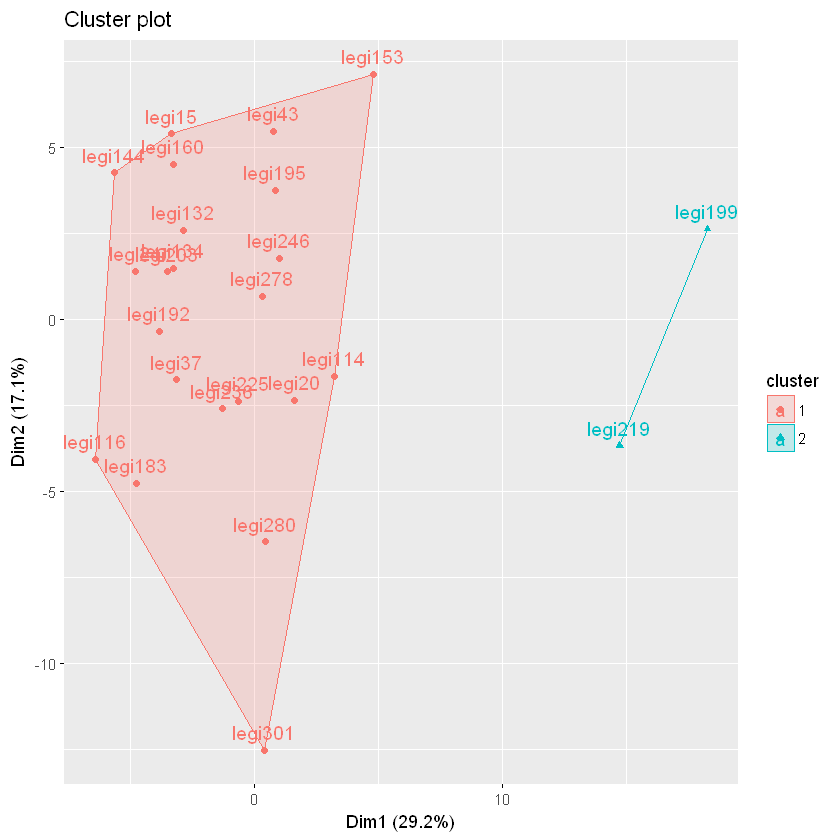

```r
gp_pam = pam(gp_data, 2)
fviz_cluster(gp_pam)
```

### 군집 1에 대한 국민 의당 의원과 공동 발의한 비율이 높은 타 당의원 Top 3

```r
#군집별 의원
gp_c1 = gp_pam$clustering[gp_pam$clustering == 1]
gp_c2 = gp_pam$clustering[gp_pam$clustering == 2]
```

```r
topSeclect(gp_data, gp_c1)
```

```
    legi248      legi85     legi233
0.010371651 0.009075194 0.008643042
   legi126     legi85    legi248
0.01384365 0.01351792 0.01302932
     legi5     legi79    legi126
0.01596974 0.01554949 0.01113679
   legi248    legi126     legi79
0.01346541 0.01331063 0.01176289
     legi79      legi92      legi12
0.010887316 0.008709853 0.007621121
     legi5    legi150    legi189
0.01733255 0.01703878 0.01615746
     legi5    legi190     legi85
0.01720047 0.01423488 0.01126928
   legi248      legi5    legi112
0.01285141 0.01084337 0.01084337
     legi73      legi79     legi150
0.009036995 0.009036995 0.008754589
     legi79      legi85      legi60
0.013397371 0.011375126 0.008847321
     legi60      legi92     legi248
0.009756098 0.009756098 0.009756098
    legi126      legi92      legi42
0.011317999 0.009127419 0.008762322
     legi5    legi190    legi168
0.03021025 0.01877934 0.01632986
    legi79    legi188    legi150
0.02112093 0.01380453 0.01283821
    legi85    legi126      legi5
0.01312336 0.01259843 0.01207349
    legi85      legi5    legi190
0.01868512 0.01764706 0.01384083
   legi248     legi35     legi92
0.01324503 0.01120734 0.01120734
    legi85    legi267      legi5
0.01824699 0.01433692 0.01205604
     legi5     legi85    legi190
0.01710587 0.01502543 0.01410079
    legi79    legi248     legi60
0.01727019 0.01615599 0.01541318
     legi5     legi60     legi79
0.02622794 0.02273089 0.01859800
    legi79    legi168    legi112
0.02287118 0.01994140 0.01984690
outPut
legi112  legi12 legi126 legi150 legi168 legi188 legi189 legi190 legi233 legi248
      2       1       5       3       2       1       1       4       1       7
legi267  legi35  legi42   legi5  legi60  legi73  legi79  legi85  legi92
      1       1       1      10       4       1       9       8       4
```

#### TOP3로 추출된 빈도수가 높은 의원들을 파악해 보았을 때, 5번/79번/85번/248번 의원 순으로 높은 빈도를 가짐

#### 의원들이 속한 당을 파악한 결과, 4명 모두 더불어민주당 소속임

### 군집 2에 대한 국민 의당 의원과 공동 발의한 비율이 높은 타 당의원 Top 3

```r
topSeclect(gp_data, gp_c2)
```

```
   legi189     legi79     legi60
0.02422003 0.02339901 0.02216749
    legi79     legi95    legi150
0.04273429 0.03202878 0.02658828
outPut
legi150 legi189  legi60  legi79  legi95
      1       1       1       2       1
```

#### TOP3로 뽑힌 빈도가 높은 의원인 79번 의원은 더불어민주당 소속 이었다.

### 바른정당

#### Cluster Plot (k=2)

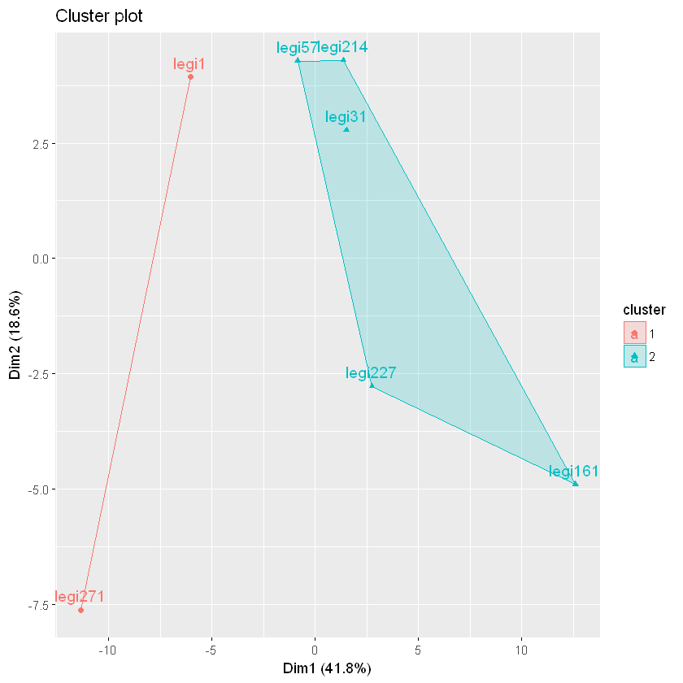

```r
bp_pam = pam(bp_data, 2)
fviz_cluster(bp_pam)
```

### 군집 1에 대한 바른 정당 의원과 공동 발의한 비율이 높은 타 당의원 Top 3

```r
#군집별 의원
bp_c1 = bp_pam$clustering[bp_pam$clustering == 1]
bp_c2 = bp_pam$clustering[bp_pam$clustering == 2]
topSeclect(bp_data, bp_c1)
```

```
   legi220    legi239    legi152
0.04913295 0.03468208 0.03034682
    legi46     legi40    legi301
0.03241379 0.02896552 0.02551724
outPut
legi152 legi220 legi239 legi301  legi40  legi46
      1       1       1       1       1       1
```

### 군집 2에 대한 바른 정당 의원과 공동 발의한 비율이 높은 타 당의원 Top 3

```r
topSeclect(bp_data, bp_c2)
```

```
    legi46    legi158    legi239
0.02947598 0.02620087 0.02620087
    legi41     legi46    legi207
0.03163580 0.02854938 0.02854938
   legi158    legi244     legi27
0.03039832 0.03039832 0.02935010
    legi46    legi158    legi239
0.03728814 0.02711864 0.02627119
    legi46     legi40    legi200
0.03424223 0.02726696 0.02726696
outPut
legi158 legi200 legi207 legi239 legi244  legi27  legi40  legi41  legi46
      3       1       1       2       1       1       1       1       4
```

#### TOP3로 뽑힌 빈도가 높은 의원인 46번/ 158번 의원은 자유한국당 소속임

#### 정의당과 무소속에 속한 의원들의 경우 각각 관측치가 1개 밖에 되지 않으므로 군집 분석이 불가능

## 2. Conclusion

### 4%의 이상치가 발견되었기에 이에 해결하기 위한 클러스터링 방법을 사용했다. Hierarchical agglomerative clustering의 세 가지 방법(single linkage, complete linkage, average linkage clustering) 중 이상치에 가장 덜 민감한 average linkage clustering을 이용하여 클러스터링을 하였다. 또한 이상치에 덜 민감한 k-medoids도 이용하여 클러스터링 하였다. 여러 가지의 모델로 클러스터링 하였지만 클러스터링 결과 같은 정당의 국회의원들끼리 클러스터링 되는 것이 확인되었다.

### 분석을 해 본 결과 자유 한국당과 바른 정당은 많은 경우 공동으로 법안을 발휘하는 것으로 파악되었다. 반면 국민 의당과 더불어 민주당, 정의당, 무소속이 많은 경우 공동으로 법안을 발휘하는 것으로 파악되었다. 평소 국민 의당이 중도 성향을 띠기 때문에 자유 한국당과 바른 정당과의 공동 발휘가 있을 것이라고 생각했지만 진보 정당과의 공동 발휘가 많은 위의 결과로 봤을때 중도보다는 진보적 성향을 더 많이 뜬다고 볼 수 있다. 무소속 의원 또한 진보 성향의 정당들과 공동 발휘 법안이 많은 것으로 볼 때 진보적 성향의 의원이라고 볼 수 있다. 따라서 위의 데이터로 볼 때 우리 나라 국회 의원들은 법안을 발휘할 때 정당을 초월한 법안을 발휘하지 않고 같은 성향, 같은 정치 철학을 가진 의원들과만 협업한다는 것을 알 수 있다.

### Data1 과 마찬가지로 Data2 또한 데이터의 양이 적기 때문에 당을 초월한 결과물을 찾는데 어려움을 겪었다. 비록 위의 데이터로는 당을 초월한 법안 발휘에 대해 찾을 수 없었지만 데이터의 양이 많고 더 많은 내용을 담고 있다면 당을 초월한 결과물을 조금이라도 찾을 수 있을 것으로 예상된다.